#Reproducible Research #Peer Project 1 #Marlin Thomas

R setup for knitr

Load libraries.

```r
library(readr)
library(ggplot2)
library(dplyr)
library(lubridate)
```

#1. Load csv file into R. Examine the file.

```r
ActivityData <- read_csv("~/activity.csv")
str(ActivityData)
```

```
## Classes 'spec_tbl_df', 'tbl_df', 'tbl' and 'data.frame': 17568 obs. of  3 variables:
##  $ steps   : num  NA NA NA NA NA NA NA NA NA NA ...
##  $ date    : Date, format: "2012-10-01" "2012-10-01" ...
##  $ interval: num  0 5 10 15 20 25 30 35 40 45 ...
##  - attr(*, "spec")=
##   .. cols(
##   ..   steps = col_double(),
##   ..   date = col_date(format = ""),
##   ..   interval = col_double()
##   .. )
```

```r
names(ActivityData)
```

```
## [1] "steps"    "date"     "interval"
```

```r
dim(ActivityData)
```

```
## [1] 17568     3
```

#2.Histogram of the total number of steps taken each day First, calculate the number of steps per day.

```r
StepsPerDay <- ActivityData %>%
  filter(!is.na(steps)) %>%
  group_by(date) %>%
  summarize(StepsPerDay = sum(steps)) %>%
  print
```

```
## # A tibble: 53 x 2
##    date       StepsPerDay
##    <date>           <dbl>
##  1 2012-10-02         126
##  2 2012-10-03       11352
##  3 2012-10-04       12116
##  4 2012-10-05       13294
##  5 2012-10-06       15420
##  6 2012-10-07       11015
##  7 2012-10-09       12811
##  8 2012-10-10        9900
##  9 2012-10-11       10304
## 10 2012-10-12       17382
## # ... with 43 more rows
```

```r
head(StepsPerDay)
```

```
## # A tibble: 6 x 2
##   date       StepsPerDay
##   <date>           <dbl>
## 1 2012-10-02         126
## 2 2012-10-03       11352
## 3 2012-10-04       12116
## 4 2012-10-05       13294
## 5 2012-10-06       15420
## 6 2012-10-07       11015
```

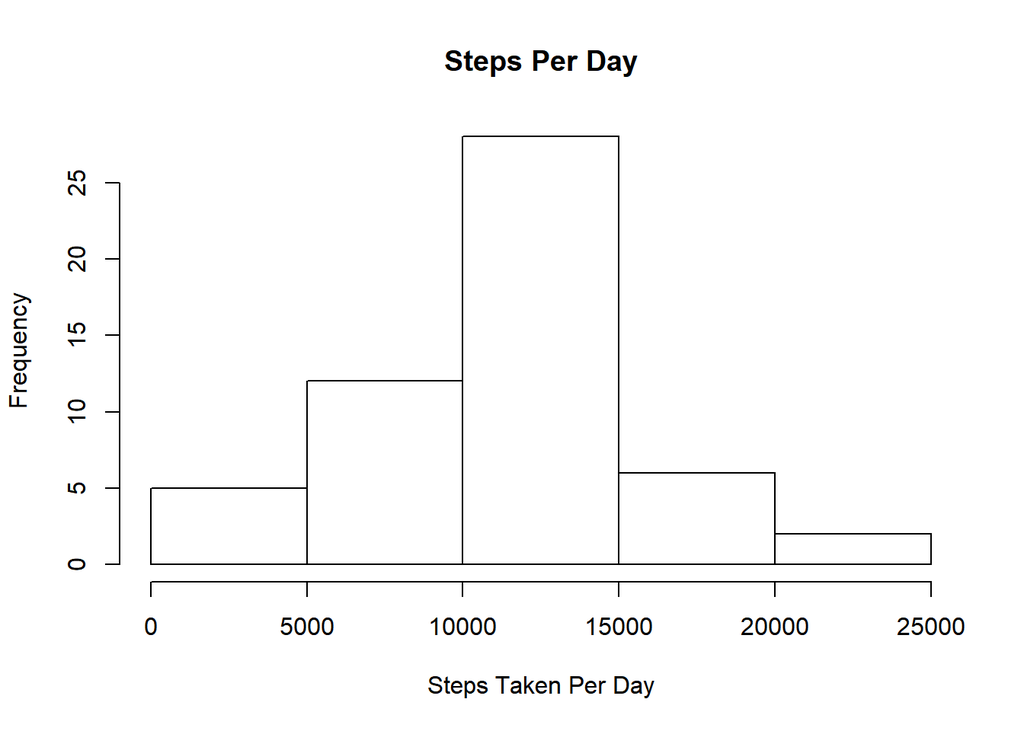

```r
hist(StepsPerDay$StepsPerDay, xlab = "Steps Taken Per Day", main  = "Steps Per Day")
```

#3. Calculate mean and median for steps per day.

```r
MeanStepsPerDay <- mean(StepsPerDay$StepsPerDay, na.rm = TRUE)
MedianStepsPerDay <- median(StepsPerDay$StepsPerDay, na.rm = TRUE)
cat ("Mean Steps Per Day: ", MeanStepsPerDay," ")
```

```
## Mean Steps Per Day:  10766.19
```

```r
cat("Median Steps Per Day:", MedianStepsPerDay)
```

```
## Median Steps Per Day: 10765
```

Calculae average number of steps per five-minute interval.

```r
AverageStepsPerInterval <- tapply(ActivityData$steps, ActivityData$interval, mean, na.rm = TRUE)
head(AverageStepsPerInterval)
```

```
##         0         5        10        15        20        25
## 1.7169811 0.3396226 0.1320755 0.1509434 0.0754717 2.0943396
```

```r
str(AverageStepsPerInterval)
```

```
##  num [1:288(1d)] 1.717 0.3396 0.1321 0.1509 0.0755 ...
##  - attr(*, "dimnames")=List of 1
##   ..$ : chr [1:288] "0" "5" "10" "15" ...
```

Generate time-series graph of the above.

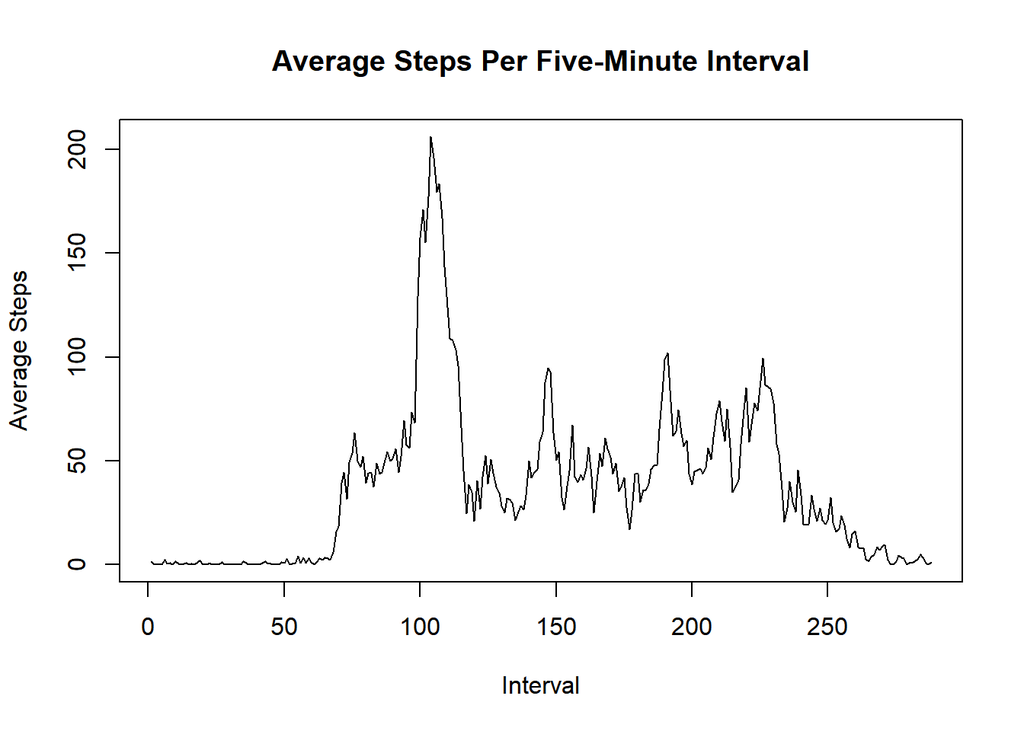

```r
plot (AverageStepsPerInterval, xlab = "Interval", ylab = "Average Steps", main = "Average Steps Per Five-Minute Interval", type = "l")
```

#5. Determine the interval with the highest average number of steps taken.

```r
HighestAverage <- max(AverageStepsPerInterval)
HighestAverage
```

```
## [1] 206.1698
```

```r
HighestInterval <- AverageStepsPerInterval[HighestAverage]
HighestInterval
```

```
##     1705
## 56.30189
```

#6. Code a strategy for imputing missing data Determine how many missing values there are.

```r
sum(is.na(ActivityData$steps))
```

```
## [1] 2304
```

To ipute missing values, develop a linear model. Then replace missing values with values generated by the linear model.

```r
Model <- lm (steps ~ interval, data = ActivityData)
Model
```

```
##
## Call:
## lm(formula = steps ~ interval, data = ActivityData)
##
## Coefficients:
## (Intercept)     interval
##   29.553871     0.006649
```

```r
summary(Model)
```

```
##
## Call:
## lm(formula = steps ~ interval, data = ActivityData)
##
## Residuals:
##    Min     1Q Median     3Q    Max
## -45.21 -39.59 -33.14 -25.95 772.36
##
## Coefficients:
##              Estimate Std. Error t value Pr(>|t|)
## (Intercept) 29.553871   1.786848  16.540  < 2e-16 ***
## interval     0.006649   0.001308   5.083 3.76e-07 ***
## ---
## Signif. codes:  0 '***' 0.001 '**' 0.01 '*' 0.05 '.' 0.1 ' ' 1
##
## Residual standard error: 111.9 on 15262 degrees of freedom
##   (2304 observations deleted due to missingness)
## Multiple R-squared:  0.00169,    Adjusted R-squared:  0.001624
## F-statistic: 25.83 on 1 and 15262 DF,  p-value: 3.765e-07
```

This model yields some statistically significant values and will be used to impute values.

```r
ImputedDataSet <- ActivityData
head(ImputedDataSet)
```

```
## # A tibble: 6 x 3
##   steps date       interval
##   <dbl> <date>        <dbl>
## 1    NA 2012-10-01        0
## 2    NA 2012-10-01        5
## 3    NA 2012-10-01       10
## 4    NA 2012-10-01       15
## 5    NA 2012-10-01       20
## 6    NA 2012-10-01       25
```

```r
for (item in 1:nrow(ImputedDataSet))
  {if( is.na(ImputedDataSet[item,]$steps))
      {
  ImputedDataSet[item,]$steps <- (29.5538 + 0.006649 * ImputedDataSet[item,]$interval)
      }


  }
head(ImputedDataSet)
```

```
## # A tibble: 6 x 3
##   steps date       interval
##   <dbl> <date>        <dbl>
## 1  29.6 2012-10-01        0
## 2  29.6 2012-10-01        5
## 3  29.6 2012-10-01       10
## 4  29.7 2012-10-01       15
## 5  29.7 2012-10-01       20
## 6  29.7 2012-10-01       25
```

```r
ImputedStepsPerDay <- ImputedDataSet %>%
  filter(!is.na(steps)) %>%
  group_by(date) %>%
  summarize(ImputedStepsPerDay = sum(steps)) %>%
  print
```

```
## # A tibble: 61 x 2
##    date       ImputedStepsPerDay
##    <date>                  <dbl>
##  1 2012-10-01             10766.
##  2 2012-10-02               126
##  3 2012-10-03             11352
##  4 2012-10-04             12116
##  5 2012-10-05             13294
##  6 2012-10-06             15420
##  7 2012-10-07             11015
##  8 2012-10-08             10766.
##  9 2012-10-09             12811
## 10 2012-10-10              9900
## # ... with 51 more rows
```

```r
head(ImputedStepsPerDay)
```

```
## # A tibble: 6 x 2
##   date       ImputedStepsPerDay
##   <date>                  <dbl>
## 1 2012-10-01             10766.
## 2 2012-10-02               126
## 3 2012-10-03             11352
## 4 2012-10-04             12116
## 5 2012-10-05             13294
## 6 2012-10-06             15420
```

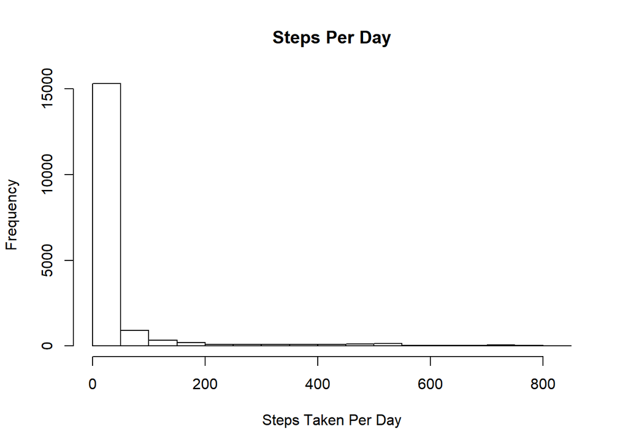

```r
hist(ImputedDataSet$steps, xlab = "Steps Taken Per Day", main  = "Steps Per Day")
```

Compare the mean of the original and the imputed data sets.

```r
MeanOriginal <- mean(StepsPerDay$StepsPerDay)
MeanImputed <- mean(ImputedStepsPerDay$ImputedStepsPerDay)
MeanOriginal
```

```
## [1] 10766.19
```

```r
MeanImputed
```

```
## [1] 10766.2
```

The difference is not significant. The imputed data have no impact on esimates for average daily steps taken. #7. Are there differences in activity patterns between weekdays and weekend. Create a copy of ActivityData Add a new variable, day Change date from factor to date. Create new variable,DOW. Store WeekDay or WeekEnd in DOW.

```r
WeekDayWeekEnd <- ActivityData
WeekDayWeekEnd$date <- as.Date(WeekDayWeekEnd$date)

NWeekEnd <- 0
NWeekDay <- 0
WeekDayWeekEnd["DOW"] <- "WeekDay"
str(WeekDayWeekEnd)
```

```
## Classes 'spec_tbl_df', 'tbl_df', 'tbl' and 'data.frame': 17568 obs. of  4 variables:
##  $ steps   : num  NA NA NA NA NA NA NA NA NA NA ...
##  $ date    : Date, format: "2012-10-01" "2012-10-01" ...
##  $ interval: num  0 5 10 15 20 25 30 35 40 45 ...
##  $ DOW     : chr  "WeekDay" "WeekDay" "WeekDay" "WeekDay" ...
##  - attr(*, "spec")=
##   .. cols(
##   ..   steps = col_double(),
##   ..   date = col_date(format = ""),
##   ..   interval = col_double()
##   .. )
```

```r
for (item in 1:nrow(WeekDayWeekEnd))
{

      DOW <- (wday(WeekDayWeekEnd$date[item]))
      if (DOW == 1 | DOW == 7)
      {
        NWeekEnd <- NWeekEnd +1
        WeekDayWeekEnd$DOW <- "WeekEnd"}
      else
      { NWeekDay <- NWeekDay + 1
        WeekDayWeekEnd$DOW <- "WeekDay"}

}
print(NWeekEnd)
```

```
## [1] 4608
```

```r
print(NWeekDay)
```

```
## [1] 12960
```

```r
StepsTypeofDay <- aggregate(WeekDayWeekEnd$steps ~ WeekDayWeekEnd$interval + WeekDayWeekEnd$DOW, WeekDayWeekEnd, mean)
names(StepsTypeofDay)
```

```
## [1] "WeekDayWeekEnd$interval" "WeekDayWeekEnd$DOW"
## [3] "WeekDayWeekEnd$steps"
```

```r
head(StepsTypeofDay)
```

```
##   WeekDayWeekEnd$interval WeekDayWeekEnd$DOW WeekDayWeekEnd$steps
## 1                       0            WeekDay            1.7169811
## 2                       5            WeekDay            0.3396226
## 3                      10            WeekDay            0.1320755
## 4                      15            WeekDay            0.1509434
## 5                      20            WeekDay            0.0754717
## 6                      25            WeekDay            2.0943396
```

```r
WeekDay <- subset (WeekDayWeekEnd, DOW = "WeekEnd")
WeekEnd <- subset (WeekDayWeekEnd, DOW = "WeekDay")
head(WeekDay)
```

```
## # A tibble: 6 x 4
##   steps date       interval DOW
##   <dbl> <date>        <dbl> <chr>
## 1    NA 2012-10-01        0 WeekDay
## 2    NA 2012-10-01        5 WeekDay
## 3    NA 2012-10-01       10 WeekDay
## 4    NA 2012-10-01       15 WeekDay
## 5    NA 2012-10-01       20 WeekDay
## 6    NA 2012-10-01       25 WeekDay
```

```r
head(WeekEnd)
```

```
## # A tibble: 6 x 4
##   steps date       interval DOW
##   <dbl> <date>        <dbl> <chr>
## 1    NA 2012-10-01        0 WeekDay
## 2    NA 2012-10-01        5 WeekDay
## 3    NA 2012-10-01       10 WeekDay
## 4    NA 2012-10-01       15 WeekDay
## 5    NA 2012-10-01       20 WeekDay
## 6    NA 2012-10-01       25 WeekDay
```

##9. Create a panel plot of the data.

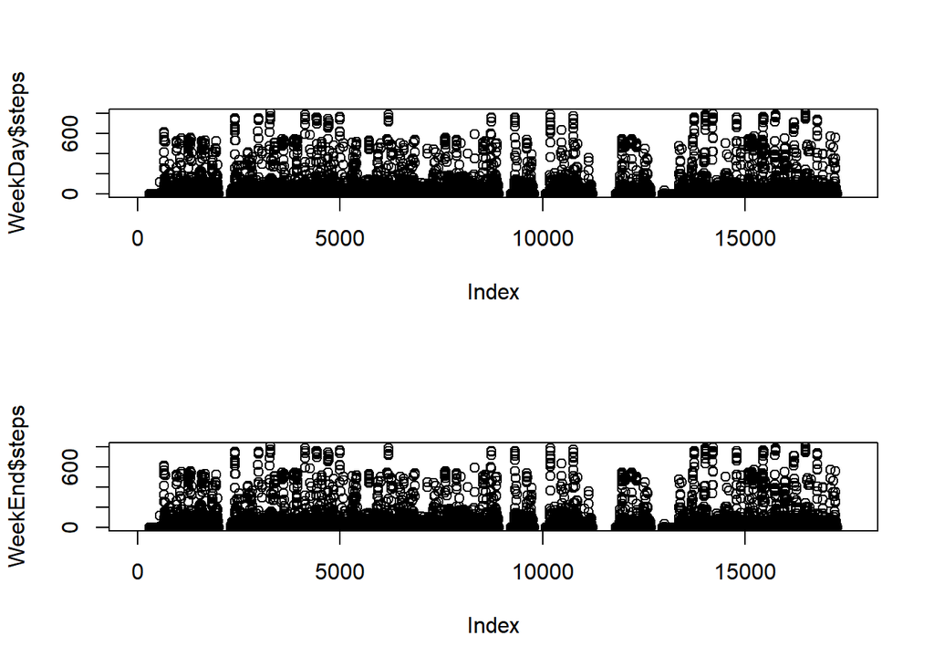

```r
par (mfrow = c(2,1))
plot(WeekDay$steps)
plot(WeekEnd$steps)
```